# Airplane Accident Severity : Group 4

Amit Shendge, Disha Kacha, Rachel Culbreath, Saniya Shinde

2023-12-13

```r
# 1. Do not provide answers/comments inside code blocks (like here) -- those are notes between coders/self and will be ignored for grading.
# 2. Make sure your knitr options are set to include all results/code to be graded in the final document.
# 3. All charts/graphs/tables should have appropriate titles/labels/captions.
# 4. Compose your answers using inline R code instead of using the code-block output as much as you can.
# 5. Your grade is also determined by the style. Even if you answer everything correctly, but the .html does not look appealing, you will not get full credit. Pay attention to the details that we mentioned in class/homework and in previous sample .Rmd files. For example, how to use #, ##, ###, ..., bold face, italics, inline codes, tables, ..., {results = "asis"}, use of colors in plots/ggplots, and so forth.
```

## Introduction

The data set our group has selected is airplane accident severity. This data set came from kaggle and we made adaptations in order to analyze the trends in our data set. Our group was interested in this data set as it is something we are interested in as flying is one of the major ways of transportation. This data set includes a comprehensive analysis of Accident_ID, Accident_Type_Code, Cabin_Temperature, Turbulence_In_gforces, Control_Metric, Total_Safety_Complaints, Days_Since_Inspection, Safety_Score, Violations, and Severity. Through these data points we were able to develop SMART questions that will allow us to determine factors that contribute to the severity of airplance accidents. This data was presented through stastical analysis and visizulizations to allow us to gain an understanding of the results of the data.

The project aims to classify the severity of an airplane based on past incidents. The dataset comprises of 10000 rows with 12 columns. Column Descriptions:

Accident_ID : unique id assigned to each row

Accident_Type_Code : type of accident

Cabin_Temperature : the last recorded temperature before the incident, measured in degrees Fahrenheit

Turbulence_In_gforces : the recorded/estimated turbulence experienced during the accident

Control_Metric : an estimation of how much control the pilot had during the incident given the factors at play

Total_Safety_Complaints : number of complaints from mechanics prior to the accident

Days_Since_Inspection : how long the plane went without inspection before the incident

Safety_Score : a measure of how safe the plane was deemed to be

Violations : number of violations that the aircraft received during inspections

Severity : a description (4 level factor) on the severity of the crash

```r
airplane = read.csv("/Users/rachelculbreath/Desktop/train.csv")
```

```r
airplane$Severity <- as.factor(airplane$Severity)
```

```r
unique(airplane$Severity)
```

```
## [1] Minor_Damage_And_Injuries
## [2] Significant_Damage_And_Fatalities
## [3] Significant_Damage_And_Serious_Injuries
## [4] Highly_Fatal_And_Damaging
## 4 Levels: Highly_Fatal_And_Damaging ... Significant_Damage_And_Serious_Injuries
```

## Bar Chart to show Airplane Count for each Severity

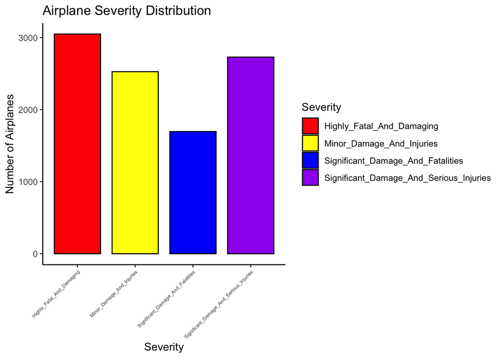

```r
library(ggplot2)
ggplot(airplane, aes(x = Severity, fill = Severity)) +
  geom_bar(stat = "count", width = 0.8, color = "black") +
  ggtitle("Airplane Severity Distribution") +
  scale_fill_manual(values = c("red", "yellow", "blue", "purple", "orange")) +  # Specify colors
  theme_classic() +
  theme(axis.text.x = element_text(angle = 45, hjust = 1,size=5)) +
  labs(x = "Severity", y = "Number of Airplanes")
```

## Boxplot showing Safety Score versus Severity

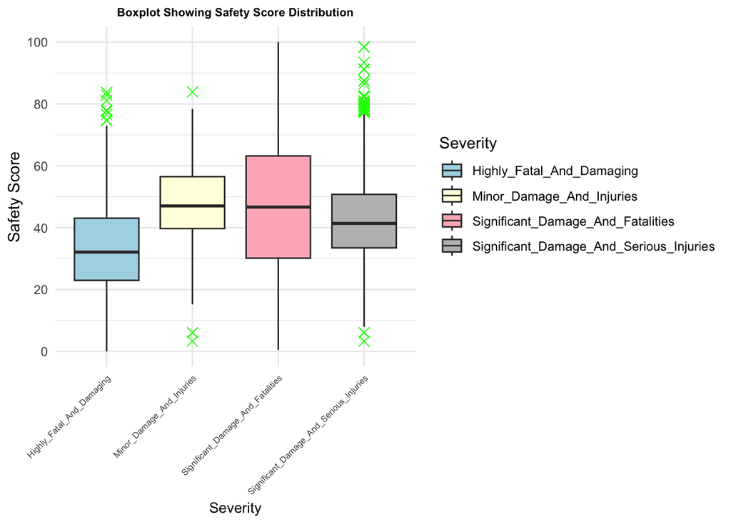

```r
ggplot(airplane, aes(x = Severity, y = Safety_Score, fill = Severity)) +
  geom_boxplot(outlier.shape = 4, outlier.color = 'green', outlier.size = 3) +
  labs(title = "Boxplot Showing Safety Score Distribution", x = "Severity", y = "Safety Score") +
  theme_minimal() +  # Apply the 'minimal' theme
  scale_fill_manual(values = c("lightblue", "lightyellow", "lightpink", "grey"), name = "Severity") +  # Set boxplot colors
  theme(
    plot.title = element_text(size = 8, face = "bold", hjust = 0.5),  # Title customization
    axis.text.x = element_text(angle = 45, hjust = 1,size=6),  # Rotate x-axis labels by 45 degrees
    axis.title.x = element_text(size = 10, vjust = 0.5)  # X-axis label customization
  ) +
  scale_y_continuous(breaks = seq(0, 100, by = 20))
```

From the above boxplot, we can see that the incidents having severity as highly fatal and damaging have safety score than the other categories, which indicates that higher severity accidents have lower safety score. We can also see that the median safety score for airplane accidents with minor damage and injuries severity is the highest, which indicates that the lower severity incidents have highest safety score. The box of significant damage and fatalities severity is relatively tall which indicates a wider spread of data. We can also see presence of outliers which are shown in green.

## Stacked Bar Plot: Violation vs. Accident Type

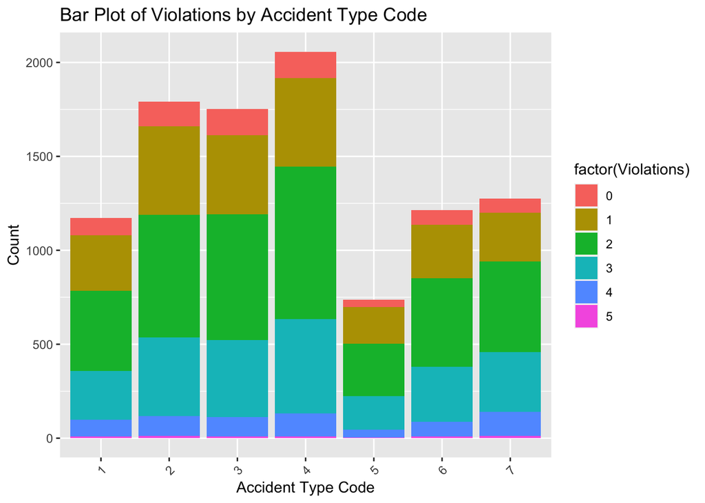

```r
library(ggplot2)

# Bar plot of Violations by Accident_Type_Code
ggplot(airplane, aes(x = factor(Accident_Type_Code), fill = factor(Violations))) +
  geom_bar(position = "stack") +
  ggtitle("Bar Plot of Violations by Accident Type Code") +
  xlab("Accident Type Code") +
  ylab("Count") +
  theme(axis.text.x = element_text(angle = 45, hjust = 1))
```

## T-test

```r
t_test_result <- t.test(airplane$Turbulence_In_gforces,airplane$Adverse_Weather_Metric)

t_test_result
```

```
##
##  Welch Two Sample t-test
##
## data:  airplane$Turbulence_In_gforces and airplane$Adverse_Weather_Metric
## t = 31, df = 12004, p-value <2e-16
## alternative hypothesis: true difference in means is not equal to 0
## 95 percent confidence interval:
##  0.118 0.134
## sample estimates:
## mean of x mean of y
##     0.381     0.256
```

Test Statistic (t): The t-value is 31.468. This value represents how many standard errors the difference between the sample means is. In this case, a higher t-value indicates a greater difference between the means.

Degrees of Freedom (df): The degrees of freedom are 12004. In the context of the t-test, higher degrees of freedom contribute to a more reliable test.

P-value: The p-value is less than 2.2e-16, which is essentially zero. The p-value represents the probability of observing such extreme results (or more extreme) under the assumption that the null hypothesis is true. A very small p-value (less than the common significance level of 0.05) suggests that you can reject the null hypothesis.

Null Hypothesis (alternative hypothesis): The null hypothesis is that the true difference in means is equal to 0. The alternative hypothesis is that the true difference in means is not equal to 0.

Confidence Interval: The 95% confidence interval for the difference in means is given as (0.1180202, 0.1337002). This interval provides a range of values within which we can be 95% confident that the true difference in means lies.

Sample Estimates (Mean of x, Mean of y): The sample mean of ‘Turbulence_In_gforces’ is 0.3814950, and the sample mean of ‘Adverse_Weather_Metric’ is 0.2556348. These values represent the average values of the two variables in your samples.

With such a small p-value (p-value < 0.05), you would reject the null hypothesis. This suggests that there is a statistically significant difference between the means of ‘Turbulence_In_gforces’ and ‘Adverse_Weather_Metric’. The confidence interval provides a range of plausible values for the true difference in means, and since it does not include 0, it further supports the rejection of the null hypothesis.

## Scatter Plot of Days_Since_Inspection versus Safety_Score

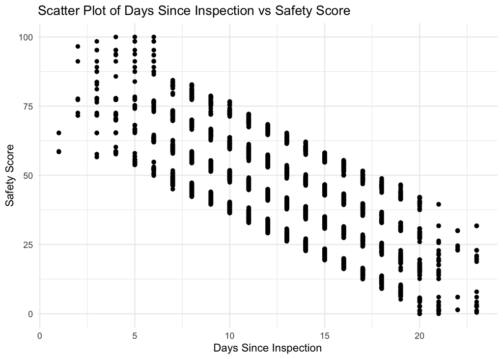

```r
ggplot(airplane, aes(x = Days_Since_Inspection, y = Safety_Score)) +
  geom_point() +
  labs(title = "Scatter Plot of Days Since Inspection vs Safety Score", x = "Days Since Inspection", y = "Safety Score") +
  theme_minimal()
```

From the above scatter plot, we can see a downward trend in data. As Days_Since_Inspection increases, Safety Score tends to decrease. More recently inspected airplanes have higher safety score. The relationship does not appear to be perfectly linear as data points are quite scattered and do not form a clear line.

## Logistic Regression Model

We will use the logistic model to predict the severity of accidents.

```r
model <- multinom(Severity ~ Safety_Score + Days_Since_Inspection + Control_Metric + Accident_Type_Code  +Adverse_Weather_Metric , data = airplane)
summary(model)
```

```
## Call:
## multinom(formula = Severity ~ Safety_Score + Days_Since_Inspection +
##     Control_Metric + Accident_Type_Code + Adverse_Weather_Metric,
##     data = airplane)
##
## Coefficients:
##                                         (Intercept) Safety_Score
## Minor_Damage_And_Injuries                     -12.7        0.183
## Significant_Damage_And_Fatalities             -11.4        0.153
## Significant_Damage_And_Serious_Injuries        -9.3        0.112
##                                         Days_Since_Inspection Control_Metric
## Minor_Damage_And_Injuries                               0.615      -0.028110
## Significant_Damage_And_Fatalities                       0.513      -0.057633
## Significant_Damage_And_Serious_Injuries                 0.364      -0.000134
##                                         Accident_Type_Code
## Minor_Damage_And_Injuries                           -0.246
## Significant_Damage_And_Fatalities                    0.374
## Significant_Damage_And_Serious_Injuries              0.123
##                                         Adverse_Weather_Metric
## Minor_Damage_And_Injuries                               -0.407
## Significant_Damage_And_Fatalities                        1.422
## Significant_Damage_And_Serious_Injuries                 -0.552
##
## Std. Errors:
##                                         (Intercept) Safety_Score
## Minor_Damage_And_Injuries                     0.380      0.00391
## Significant_Damage_And_Fatalities             0.392      0.00401
## Significant_Damage_And_Serious_Injuries       0.344      0.00350
##                                         Days_Since_Inspection Control_Metric
## Minor_Damage_And_Injuries                              0.0156        0.00284
## Significant_Damage_And_Fatalities                      0.0162        0.00306
## Significant_Damage_And_Serious_Injuries                0.0139        0.00253
##                                         Accident_Type_Code
## Minor_Damage_And_Injuries                           0.0288
## Significant_Damage_And_Fatalities                   0.0286
## Significant_Damage_And_Serious_Injuries             0.0253
##                                         Adverse_Weather_Metric
## Minor_Damage_And_Injuries                                0.128
## Significant_Damage_And_Fatalities                        0.125
## Significant_Damage_And_Serious_Injuries                  0.131
##
## Residual Deviance: 22068
## AIC: 22104
```

```r
training_pred <- predict(model, airplane, type="class")

confusionMatrix(training_pred, airplane$Severity)
```

```
## Confusion Matrix and Statistics
##
##                                          Reference
## Prediction                                Highly_Fatal_And_Damaging
##   Highly_Fatal_And_Damaging                                    2478
##   Minor_Damage_And_Injuries                                     403
##   Significant_Damage_And_Fatalities                             134
##   Significant_Damage_And_Serious_Injuries                        34
##                                          Reference
## Prediction                                Minor_Damage_And_Injuries
##   Highly_Fatal_And_Damaging                                      12
##   Minor_Damage_And_Injuries                                    1692
##   Significant_Damage_And_Fatalities                             234
##   Significant_Damage_And_Serious_Injuries                       589
##                                          Reference
## Prediction                                Significant_Damage_And_Fatalities
##   Highly_Fatal_And_Damaging                                             750
##   Minor_Damage_And_Injuries                                             342
##   Significant_Damage_And_Fatalities                                     430
##   Significant_Damage_And_Serious_Injuries                               173
##                                          Reference
## Prediction                                Significant_Damage_And_Serious_Injuries
##   Highly_Fatal_And_Damaging                                                   214
##   Minor_Damage_And_Injuries                                                   318
##   Significant_Damage_And_Fatalities                                           290
##   Significant_Damage_And_Serious_Injuries                                    1907
##
## Overall Statistics
##
##                Accuracy : 0.651
##                  95% CI : (0.641, 0.66)
##     No Information Rate : 0.305
##     P-Value [Acc > NIR] : <2e-16
##
##                   Kappa : 0.523
##
##  Mcnemar's Test P-Value : <2e-16
##
## Statistics by Class:
##
```

[output cut: 21 more lines]

```
## Pos Pred Value                                          0.395
## Neg Pred Value                                          0.858
## Prevalence                                              0.170
## Detection Rate                                          0.043
## Detection Prevalence                                    0.109
## Balanced Accuracy                                       0.587
##                      Class: Significant_Damage_And_Serious_Injuries
## Sensitivity                                                   0.699
## Specificity                                                   0.891
## Pos Pred Value                                                0.706
## Neg Pred Value                                                0.887
## Prevalence                                                    0.273
## Detection Rate                                                0.191
## Detection Prevalence                                          0.270
## Balanced Accuracy                                             0.795
```

```r
model <- multinom(Severity ~ Safety_Score + Days_Since_Inspection + Control_Metric + Accident_Type_Code + Adverse_Weather_Metric , data = airplane)
```

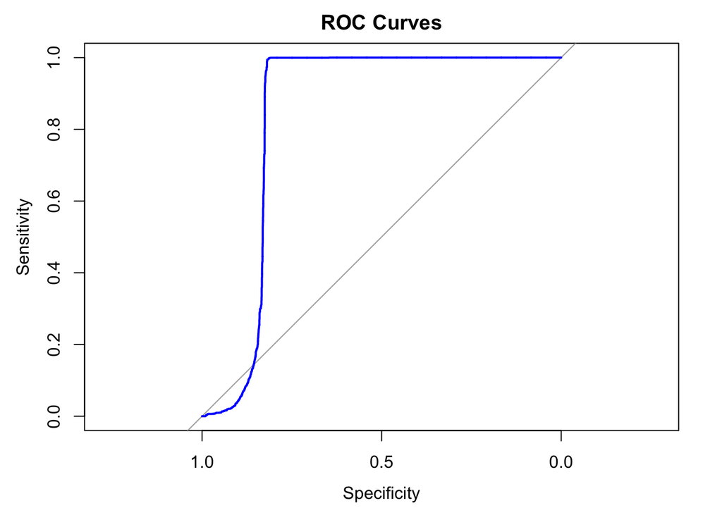

```r
probs <- predict(model, airplane, type="probs")

# Assuming 'Severity' has three levels: Low, Medium, High
roc_low <- roc(airplane$Severity, probs[, "Highly_Fatal_And_Damaging"])
roc_medium <- roc(airplane$Severity, probs[, "Minor_Damage_And_Injuries"])
roc_high <- roc(airplane$Severity, probs[, "Significant_Damage_And_Fatalities"])
roc_high2 <- roc(airplane$Severity, probs[, "Significant_Damage_And_Serious_Injuries"])

# Plot ROC Curve
plot(roc_low, main="ROC Curves", col="blue")
```

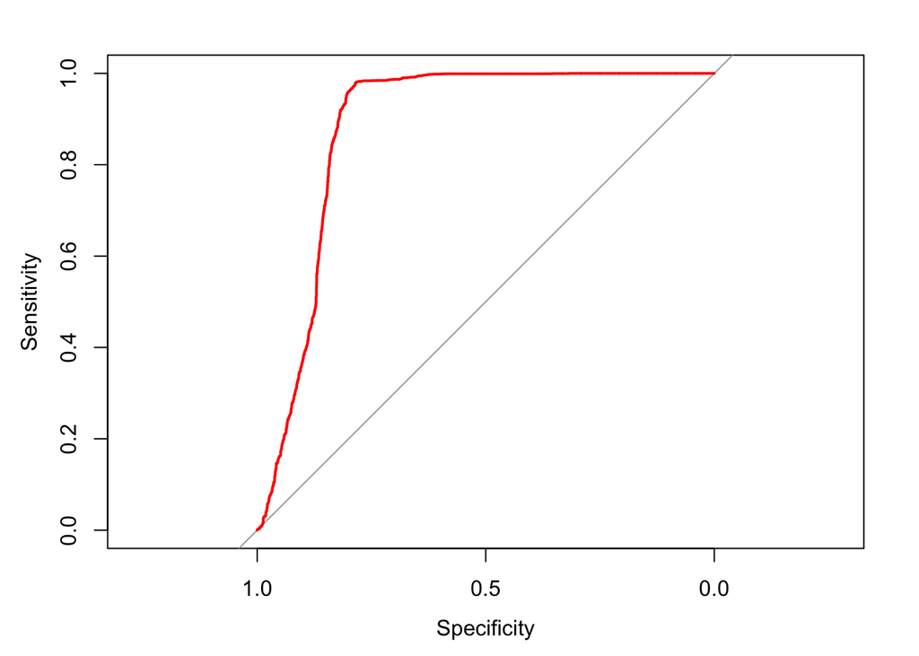

```r
plot(roc_medium, col="red")
```

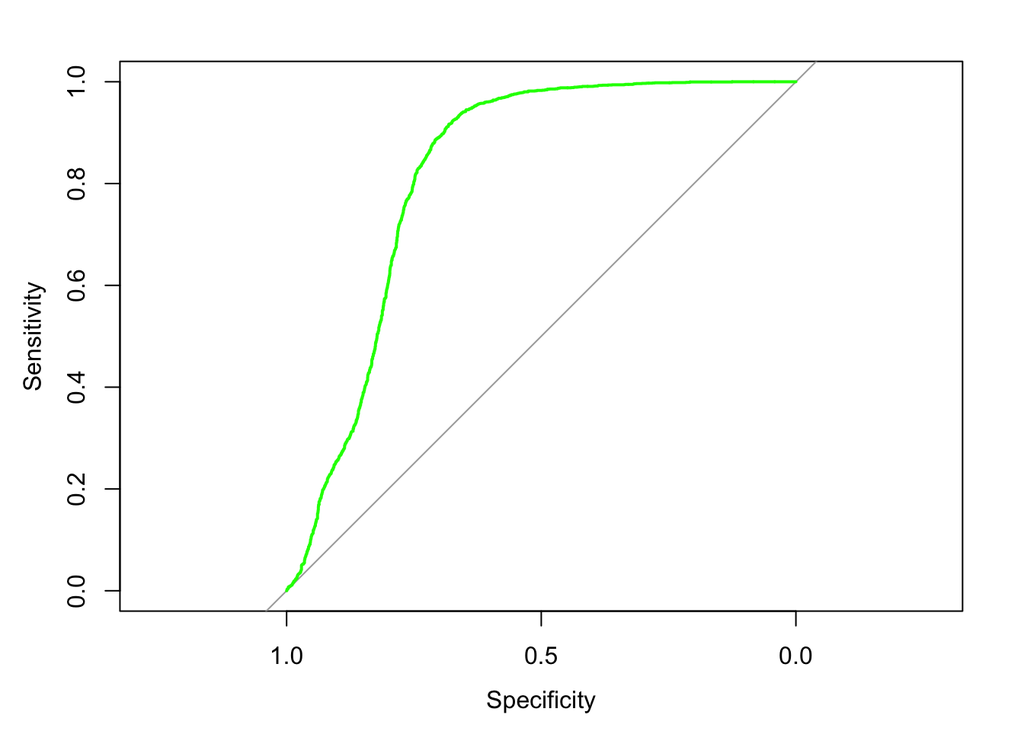

```r
plot(roc_high, col="green")
```

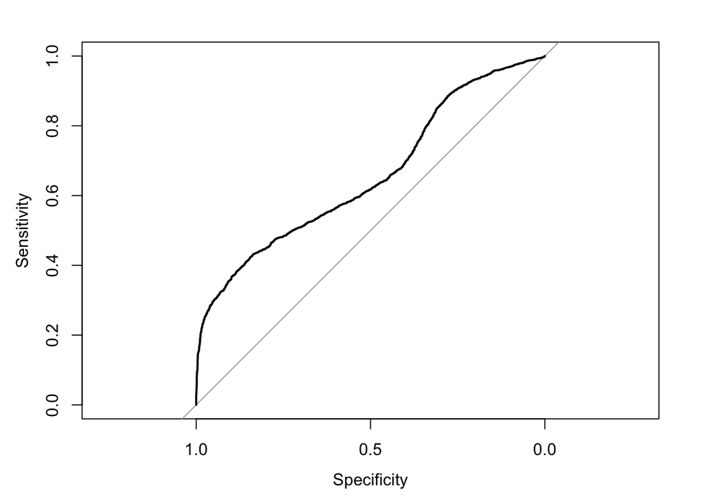

```r
plot(roc_high2, col="black")
```